# STAT 471/571/701 Modern Data Mining - HW 1

Group Member Bingying Feng

Group Member He Zhang

Group Member Dingzhe Leng

Due: 11:59PM February 3, 2019

## Question 0

Review the code and concepts covered during lecture.

# Simple Regression

## Question 1

This exercise is designed to help you understand the linear model using simulations. In this exercise, we will generate $(x_i, y_i)$ pairs so that all linear model assumptions are met.

Presume that $x$ and $y$ are linearly related with a normal error $\epsilon$ , such that $y = 1 + 1.2x + \epsilon$. The standard deviation of the error is $\sigma = 2$.

We can create a sample input vector ($n = 40$) for $x$ with the following code:

```r
# Generates a vector of size 40 with equally spaced values between 0 and 1, inclusive
x <- seq(0, 1, length = 40)
```

### Q1.1 Generate data

Create a corresponding output vector for $y$ according to the equation given above. Use `set.seed(1)`. Then, create a scatterplot with $\left(x, y\right)$ pairs. Base R plotting is acceptable, but if you can, please attempt to use `ggplot2` to create the plot. Make sure to have clear labels and sensible titles on your plots.

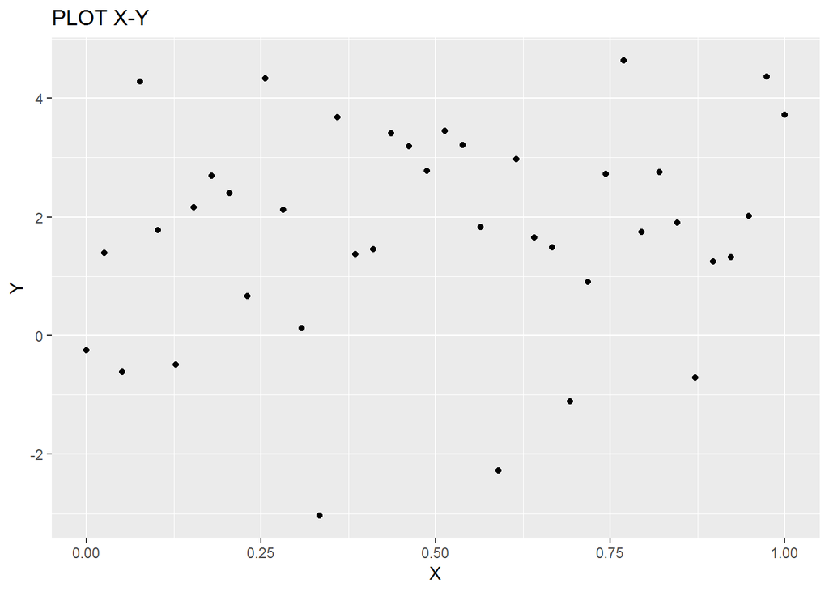

```r
#generate eps
set.seed(1)
eps<-rnorm(40,0,2)
#generate y
y<-1+1.2*x+eps
simple.reg<-data.frame(x,y,eps)
#create plot
plot1<-ggplot(simple.reg,aes(x=simple.reg$x, y = simple.reg$y)) +
       geom_point()+
       ggtitle("PLOT X-Y")+
       xlab("X")+
       ylab("Y")
plot1
```

### Q1.2 Understand the model

1. Find the LS estimates of $\beta_0$ and $\beta_1$, using the `lm()` function. What are the true values of $\beta_0$ and $\beta_1$? Do the estimates look to be good?
2. What is your RSE for this linear model fit? Is it close to $\sigma = 2$?
3. What is the 95% confidence interval for $\beta_1$? Does this confidence interval capture the true $\beta_1$?
4. Overlay the LS estimates and the true lines of the mean function onto a copy of the scatterplot you made above.

```r
fit1<-lm(y~x,data=simple.reg)
summary(fit1)
```

```
##
## Call:
## lm(formula = y ~ x, data = simple.reg)
##
## Residuals:
##     Min      1Q  Median      3Q     Max
## -4.6624 -0.8797  0.0139  1.2468  2.8823
##
## Coefficients:
##             Estimate Std. Error t value Pr(>|t|)
## (Intercept)   1.3308     0.5569   2.390   0.0219 *
## x             0.9064     0.9585   0.946   0.3503
## ---
## Signif. codes:  0 '***' 0.001 '**' 0.01 '*' 0.05 '.' 0.1 ' ' 1
##
## Residual standard error: 1.794 on 38 degrees of freedom
## Multiple R-squared:  0.02299,    Adjusted R-squared:  -0.002718
## F-statistic: 0.8943 on 1 and 38 DF,  p-value: 0.3503
```

```r
summary(fit1)$sigma ##RSS <- sum((fit1$res)^2)  sqrt(RSS/fit1$df)
```

```
## [1] 1.794303
```

```r
confint(fit1)
```

```
##                 2.5 %   97.5 %
## (Intercept)  0.203384 2.458284
## x           -1.033966 2.846838
```

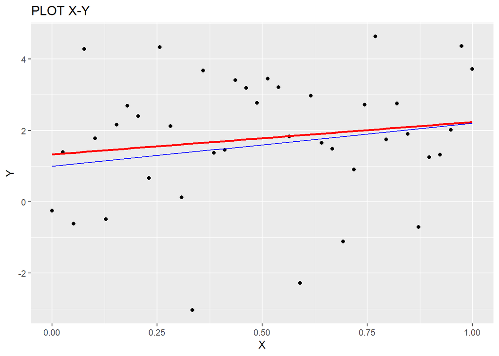

```r
y_mean<-1+1.2*x
simple.reg<-data.frame(simple.reg,y_mean)
plot1+
  geom_smooth(method="lm", se = F,color = "red") +
  geom_line(aes(x,y_mean),linetype=1,color="blue")
```

1. The true values of $\beta_0$ and $\beta_1$ are 1 and 1.2 respectively.For $\beta_0$, it’s acceptable. At $\alpha$=0.05, we can reject null hypothesis that $\beta_0$ equals zero.For $\beta_1$, we fail to reject the null hypothesis, but $\beta_1$ is not zero in fact. Overall, the estimates don’t look good.
2. RSE for this linear model fit is 1.794. Yes, it’s close to $\sigma = 2$
3. The 95% confidence interval for $\beta_1$ is [-1.03,2.85]. Yes, it captures the true $\beta_1$.

### Q1.3 Model diagnoses

1. Provide residual plot of `x = fitted y`, `y = residuals`.
2. Provide a QQ-Normal plot of the residuals
3. Comment on how well the model assumptions are met for the sample you used.

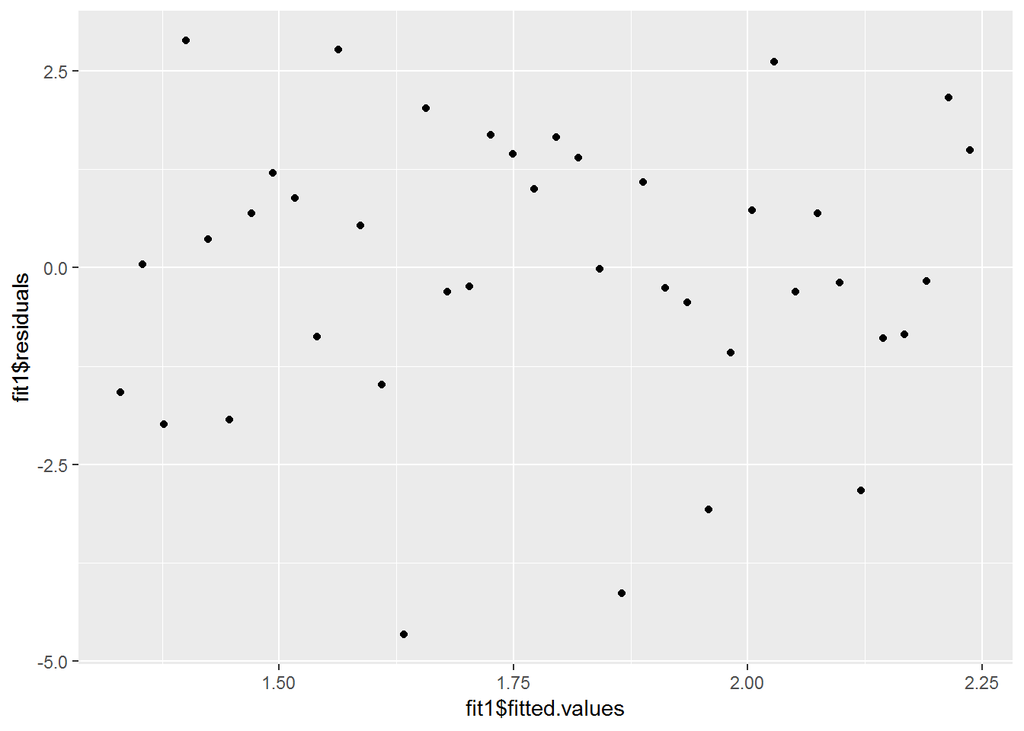

```r
plot2<-ggplot(fit1,aes(fit1$fitted.values,fit1$residuals))+
       geom_point()
plot2
```

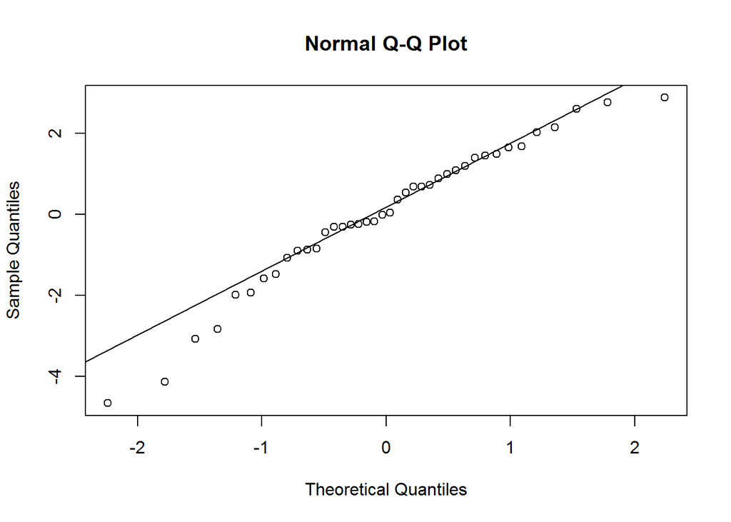

```r
qqnorm(fit1$residuals)
qqline(fit1$residuals)
```

3. From the residual plot, we can see that the volatility of residual doesn’t change accordding to fitted value, which meets our assumption that variances are the same to all the levels of x.The normal Q-Q plot doesn’t fit very well. The lower tail and upper tail are both off the line. However, most of the points are on the line so it’s acceptable, which meets the assumption of normality.

### Q1.4 Understand sampling distribution and confidence intervals

This part aims to help you understand the notion of sampling statistics and confidence intervals. Let’s concentrate on estimating the slope only.

Generate 100 samples of size $n = 40$, and estimate the slope coefficient from each sample. We include some sample code below, which should guide you in setting up the simulation. Note: this code is easier to follow but suboptimal; see the appendix for a more optimal R-like way to run this simulation.

```r
# Inializing variables. Note b_1, upper_ci, lower_ci are vectors
x <- seq(0, 1, length = 40)
n_sim <- 100              # number of simulations
b1 <- 0                   # n_sim many LS estimates of beta_1 (=1.2). Initialize to 0 for now
upper_ci <- 0             # upper bound for beta_1. Initialize to 0 for now.
lower_ci <- 0             # lower bound for beta_1. Initialize to 0 for now.
t_star <- qt(0.975, 38)   # Food for thought: why 38 instead of 40? What is t_star? 38 is the degree of freedom because we have two coeffiecnts to estimate; t_star is the t-value with dt at 38 at alpha=0.05

# Perform the simulation
for (i in 1:n_sim){
  y <- 1 + 1.2 * x + rnorm(40, sd = 2)
  lse <- lm(y ~ x)
  lse_output <- summary(lse)$coefficients
  se <- lse_output[2, 2]
  b1[i] <- lse_output[2, 1]
  upper_ci[i] <- b1[i] + t_star * se
  lower_ci[i] <- b1[i] - t_star * se
}
results <- as.data.frame(cbind(se, b1, upper_ci, lower_ci))

# remove unecessary variables from our workspace
rm(se, b1, upper_ci, lower_ci, x, n_sim, b1, t_star, lse, lse_out)
```

1. Summarize the LS estimates of $\beta_1$ (stored in `results$b1`). Does the sampling distribution agree with theory?
2. How many of your 95% confidence intervals capture the true $\beta_1$? Display your confidence intervals graphically.

```r
summary(results$b1)
```

```
##    Min. 1st Qu.  Median    Mean 3rd Qu.    Max.
## -1.3576  0.2299  1.0496  1.0552  1.8660  3.9681
```

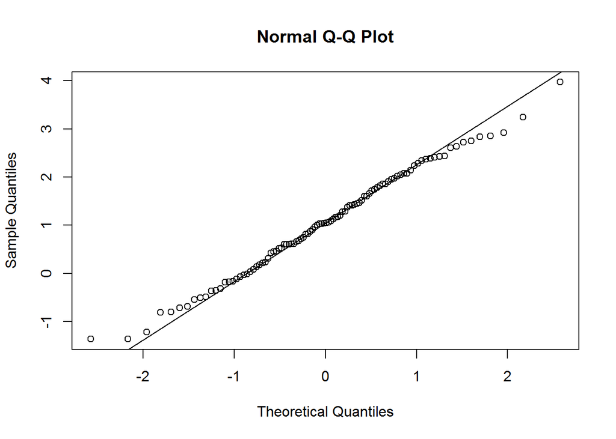

```r
qqnorm(results$b1)
qqline(results$b1)
```

```r
results %>%
  filter(results$upper_ci>=1.2&results$lower_ci<=1.2)%>%
  summarize(count=n())
```

```
##   count
## 1    96
```

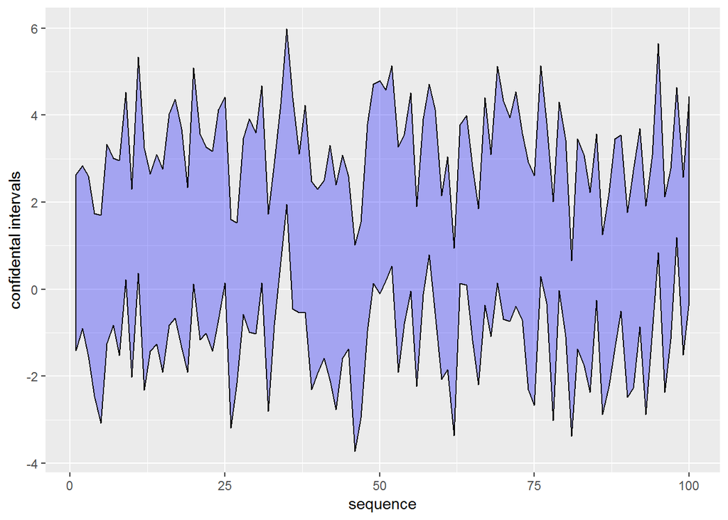

```r
  ggplot(results,aes(1:100,results$lower_ci))+
  geom_ribbon(aes(ymin=results$lower_ci,ymax=results$upper_ci),colour="black",alpha=0.3,fill="blue")+
  xlab("sequence")+
  ylab("confidental intervals")
```

1. The mean of LS estimates of $\beta_1$ is 1.05,which is close to the true value 1.2. We fit QQ-normal plot to them.It’s acceptable althought the upper tail is a little bit off the line. So, it agrees with theory.
2. 96 confidence intervals capture the true $\beta_1$.

## Question 2

This question is about Major League Baseball (MLB) and team payrolls. Guiding questions: how do salaries paid to players affect team wins? How could we model win propensity?

We have put together a dataset consisting of the winning records and the payroll data of all 30 MLB teams from 1998 to 2014. There are 54 variables in the dataset, including:

- `payroll`: total team payroll (in $billions) over the 17-year period
- `avgwin`: the aggregated win percentage over the 17-year period
- winning percentage and payroll (in $millions) for each team are also broken down for each year.

The data is stored as `MLPayData_Total.csv` on Canvas.

```r
setwd("I:/homework") #setwd("E:/Semester 2/Modern data mining/Week_1")
salary<- read.csv("MLPayData_Total.csv",sep=",")
```

### Q2.1 Exploratory questions

For each of the following questions, there is a `dplyr` solution that you should try to answer with.

1. Which 5 teams spent the most money in total between years 2000 and 2004, inclusive?
2. Between 1999 and 2000, inclusive, which team(s) “improved” the most? That is, had the biggest percentage gain in wins?
3. Using `ggplot`, pick a single year, and plot the number of games won vs. `payroll` for that year (`payroll` on x-axis). You may use any ‘geom’ that makes sense, such as a scatterpoint or a label with the point’s corresponding team name.

```r
#i
salary<- salary %>%
  mutate(total_00_04= p2000+p2001+p2002+p2003+p2004)
head(arrange(salary,desc(total_00_04))%>%select(Team.name.2014,total_00_04),5)
```

```
##        Team.name.2014 total_00_04
## 1    New York Yankees    663.8441
## 2      Boston Red Sox    521.0203
## 3 Los Angeles Dodgers    487.5232
## 4       New York Mets    485.1235
## 5      Atlanta Braves    464.6113
```

```r
#ii
salary<- salary %>%
  mutate(change_19_20= X2000/X1999-1)  # or mutate(change_19_20= X2000.pct-X1999.pct)
salary %>% select(Team.name.2014,change_19_20)%>% filter(change_19_20== max(change_19_20))
```

```
##        Team.name.2014 change_19_20
## 1   Chicago White Sox    0.2666667
## 2 St. Louis Cardinals    0.2666667
```

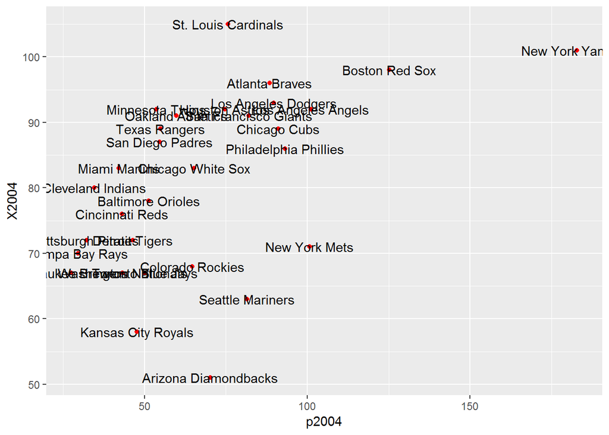

```r
#iii
ggplot(salary)+
  geom_point(aes(x=p2004,y=X2004),col="red")+
  geom_text(aes(x = p2004, y = X2004, label=Team.name.2014))
```

i.By descending order, New York Yankees, Boston Red Sox, Los Angeles Dodgers, New York Mets, and Atlanta Braves spent the most money in total between years 2000 and 2004.

2. Between 1999 and 2000, both Chicago White Sox and St. Louis Cardinals improved the most, with the percentage gain in wins at 26.7%.
3. Scatterplot with labels of team names.

### Q2.2

For a given year, is `payroll` a significant variable in predicting the winning percentage of that year? Choose a single year and run a regression to examine this. You may try this for a few different years. You can do this programmatically (i.e. for every year) if you are interested, but it is not required.

```r
for(i in 1:5) {
  M<- lm(salary[,52-i+1]~salary[,6+i-1],data=salary)
  print(summary(M))
}
```

```
##
## Call:
## lm(formula = salary[, 52 - i + 1] ~ salary[, 6 + i - 1], data = salary)
##
## Residuals:
##       Min        1Q    Median        3Q       Max
## -0.103384 -0.045839  0.002309  0.035566  0.109632
##
## Coefficients:
##                      Estimate Std. Error t value Pr(>|t|)
## (Intercept)         0.4473224  0.0307196  14.561 1.37e-14 ***
## salary[, 6 + i - 1] 0.0009464  0.0005164   1.833   0.0775 .
## ---
## Signif. codes:  0 '***' 0.001 '**' 0.01 '*' 0.05 '.' 0.1 ' ' 1
##
## Residual standard error: 0.05935 on 28 degrees of freedom
## Multiple R-squared:  0.1071, Adjusted R-squared:  0.07522
## F-statistic: 3.359 on 1 and 28 DF,  p-value: 0.0775
##
##
## Call:
## lm(formula = salary[, 52 - i + 1] ~ salary[, 6 + i - 1], data = salary)
##
## Residuals:
##       Min        1Q    Median        3Q       Max
## -0.117506 -0.056690 -0.008117  0.047976  0.203679
##
## Coefficients:
##                      Estimate Std. Error t value Pr(>|t|)
## (Intercept)         0.4288775  0.0398939  10.750  1.9e-11 ***
## salary[, 6 + i - 1] 0.0011036  0.0005791   1.906    0.067 .
## ---
## Signif. codes:  0 '***' 0.001 '**' 0.01 '*' 0.05 '.' 0.1 ' ' 1
##
## Residual standard error: 0.07705 on 28 degrees of freedom
## Multiple R-squared:  0.1148, Adjusted R-squared:  0.08319
## F-statistic: 3.631 on 1 and 28 DF,  p-value: 0.06701
##
##
## Call:
```

[output cut: 39 more lines]

```
##
## Residuals:
##      Min       1Q   Median       3Q      Max
## -0.18731 -0.02907  0.01060  0.04700  0.13887
##
## Coefficients:
##                      Estimate Std. Error t value Pr(>|t|)
## (Intercept)         0.4095794  0.0313668  13.058 1.98e-13 ***
## salary[, 6 + i - 1] 0.0013182  0.0004146   3.179  0.00359 **
## ---
## Signif. codes:  0 '***' 0.001 '**' 0.01 '*' 0.05 '.' 0.1 ' ' 1
##
## Residual standard error: 0.07267 on 28 degrees of freedom
## Multiple R-squared:  0.2652, Adjusted R-squared:  0.239
## F-statistic: 10.11 on 1 and 28 DF,  p-value: 0.003588
```

```r
# every year
#for(i in 1:17) {
#  E<- lm(salary[,54-i+1]~salary[,4+i-1],data=salary)
#  print(summary(E))
#}
```

I ran regressions for years between 2000 and 2004 (inclusive).I set the significance level at 0.05 and compare the p-value of “payroll” to this benchmark. In the first two years, “payroll” is not a significant variable in predicting the winning percentage; in the last three years, it is a significant variable in such prediction.

### Q2.3

With the aggregated information, use regression to analyze total payroll and overall winning percentage. Run appropriate model(s) to answer the following questions:

1. In this analysis, do the [Boston Red Sox](http://darkroom.baltimoresun.com/wp-content/uploads/2013/10/SP.BOSTON28P2.jpg) perform reasonably well given their total amount spent on payroll? [Use a 95% interval.]
2. Given their winning percentage, how much would you have expected the Oakland A’s to have spent on total payroll? [Use a 95% interval.]

```r
#i
M<- lm(avgwin~ payroll, data= salary)
summary(M)
```

```
##
## Call:
## lm(formula = avgwin ~ payroll, data = salary)
##
## Residuals:
##       Min        1Q    Median        3Q       Max
## -0.040034 -0.017492  0.000936  0.010954  0.070302
##
## Coefficients:
##             Estimate Std. Error t value Pr(>|t|)
## (Intercept)  0.42260    0.01534  27.555  < 2e-16 ***
## payroll      0.06137    0.01173   5.233 1.47e-05 ***
## ---
## Signif. codes:  0 '***' 0.001 '**' 0.01 '*' 0.05 '.' 0.1 ' ' 1
##
## Residual standard error: 0.02697 on 28 degrees of freedom
## Multiple R-squared:  0.4944, Adjusted R-squared:  0.4763
## F-statistic: 27.38 on 1 and 28 DF,  p-value: 1.469e-05
```

```r
salary%>% select(Team.name.2014,payroll,avgwin)%>% filter(Team.name.2014== "Boston Red Sox")
```

```
##   Team.name.2014  payroll    avgwin
## 1 Boston Red Sox 1.972359 0.5487172
```

```r
new <- data.frame(payroll=c(1.972359))
CIpred <- predict(M, new, interval="prediction", se.fit=TRUE,level=0.95)
CIpred
```

```
## $fit
##         fit       lwr       upr
## 1 0.5436382 0.4847828 0.6024936
##
## $se.fit
## [1] 0.009916126
##
## $df
## [1] 28
##
## $residual.scale
## [1] 0.02696692
```

```r
#ii
M_inverse<- lm(payroll~ avgwin, data=salary)
summary (M_inverse)
```

```
##
## Call:
## lm(formula = payroll ~ avgwin, data = salary)
##
## Residuals:
##      Min       1Q   Median       3Q      Max
## -0.76735 -0.18705 -0.03714  0.16633  0.78427
##
## Coefficients:
##             Estimate Std. Error t value Pr(>|t|)
## (Intercept)  -2.7784     0.7697  -3.610  0.00118 **
## avgwin        8.0563     1.5396   5.233 1.47e-05 ***
## ---
## Signif. codes:  0 '***' 0.001 '**' 0.01 '*' 0.05 '.' 0.1 ' ' 1
##
## Residual standard error: 0.309 on 28 degrees of freedom
## Multiple R-squared:  0.4944, Adjusted R-squared:  0.4763
## F-statistic: 27.38 on 1 and 28 DF,  p-value: 1.469e-05
```

```r
salary%>% select(Team.name.2014,payroll,avgwin)%>% filter(Team.name.2014== "Oakland Athletics")
```

```
##      Team.name.2014  payroll    avgwin
## 1 Oakland Athletics 0.840934 0.5445067
```

```r
new_1 <- data.frame(avgwin=c(0.5445067))
CIpred_1 <- predict(M_inverse, new_1, interval="prediction", se.fit=TRUE,level=0.95)
CIpred_1
```

```
## $fit
##        fit       lwr      upr
## 1 1.608288 0.9488245 2.267751
##
## $se.fit
## [1] 0.090433
##
## $df
## [1] 28
##
## $residual.scale
## [1] 0.3089771
```

i To answer this question, I 1) run a regression of total payroll and overall winning percentage, 2) calculated the predicted winning percentage using the payroll by Boston Red Sox, 3) calculated the prediction interval for Boston Red Sox, and 4) see if the team’s winning percentage is within this interval.

ii To answer this question, I have to run another model to predict total payroll using winning percentage. Using a 95% prediction interval, I would expext Oakland Athletics to have spent from 0.9488 to 2.2678 billion dollars.

# Multiple Regression

## Question 3:

You can access the necessary data with the following code:

```r
# Read in the Auto dataset
auto_data <- ISLR::Auto
```

Get familiar with this dataset first. Tip: you can use the command `?ISLR::Auto` to view a description of the dataset.

### Q3.1

Explore the data, with particular focus on pairwise plots and summary statistics. Briefly summarize your findings and any peculiarities in the data.

```r
dim(auto_data)
```

```
## [1] 392   9
```

```r
summary(auto_data)
```

```
##       mpg          cylinders      displacement     horsepower
##  Min.   : 9.00   Min.   :3.000   Min.   : 68.0   Min.   : 46.0
##  1st Qu.:17.00   1st Qu.:4.000   1st Qu.:105.0   1st Qu.: 75.0
##  Median :22.75   Median :4.000   Median :151.0   Median : 93.5
##  Mean   :23.45   Mean   :5.472   Mean   :194.4   Mean   :104.5
##  3rd Qu.:29.00   3rd Qu.:8.000   3rd Qu.:275.8   3rd Qu.:126.0
##  Max.   :46.60   Max.   :8.000   Max.   :455.0   Max.   :230.0
##
##      weight      acceleration        year           origin
##  Min.   :1613   Min.   : 8.00   Min.   :70.00   Min.   :1.000
##  1st Qu.:2225   1st Qu.:13.78   1st Qu.:73.00   1st Qu.:1.000
##  Median :2804   Median :15.50   Median :76.00   Median :1.000
##  Mean   :2978   Mean   :15.54   Mean   :75.98   Mean   :1.577
##  3rd Qu.:3615   3rd Qu.:17.02   3rd Qu.:79.00   3rd Qu.:2.000
##  Max.   :5140   Max.   :24.80   Max.   :82.00   Max.   :3.000
##
##                  name
##  amc matador       :  5
##  ford pinto        :  5
##  toyota corolla    :  5
##  amc gremlin       :  4
##  amc hornet        :  4
##  chevrolet chevette:  4
##  (Other)           :365
```

```r
str(auto_data)
```

```
## 'data.frame':    392 obs. of  9 variables:
##  $ mpg         : num  18 15 18 16 17 15 14 14 14 15 ...
##  $ cylinders   : num  8 8 8 8 8 8 8 8 8 8 ...
##  $ displacement: num  307 350 318 304 302 429 454 440 455 390 ...
##  $ horsepower  : num  130 165 150 150 140 198 220 215 225 190 ...
##  $ weight      : num  3504 3693 3436 3433 3449 ...
##  $ acceleration: num  12 11.5 11 12 10.5 10 9 8.5 10 8.5 ...
##  $ year        : num  70 70 70 70 70 70 70 70 70 70 ...
##  $ origin      : num  1 1 1 1 1 1 1 1 1 1 ...
##  $ name        : Factor w/ 304 levels "amc ambassador brougham",..: 49 36 231 14 161 141 54 223 241 2 ...
```

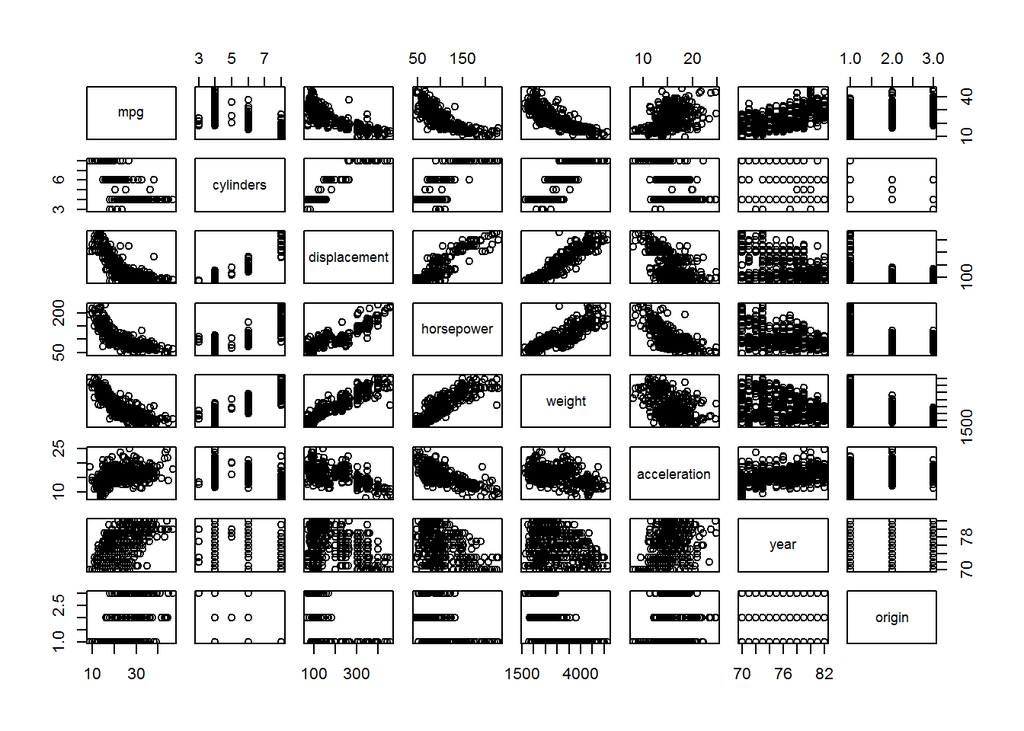

```r
pairs(auto_data[,1:8])
```

### Q3.2

What effect does `time` have on `MPG`?

1. Start with a simple regression of `mpg` vs. `year` and report R’s `summary` output. Is `year` a significant variable at the .05 level? State what effect `year` has on `mpg`, if any, according to this model.

```r
fit1 <- lm(mpg~year, data=auto_data)
summary(fit1)
```

```
##
## Call:
## lm(formula = mpg ~ year, data = auto_data)
##
## Residuals:
##      Min       1Q   Median       3Q      Max
## -12.0212  -5.4411  -0.4412   4.9739  18.2088
##
## Coefficients:
##              Estimate Std. Error t value Pr(>|t|)
## (Intercept) -70.01167    6.64516  -10.54   <2e-16 ***
## year          1.23004    0.08736   14.08   <2e-16 ***
## ---
## Signif. codes:  0 '***' 0.001 '**' 0.01 '*' 0.05 '.' 0.1 ' ' 1
##
## Residual standard error: 6.363 on 390 degrees of freedom
## Multiple R-squared:  0.337,  Adjusted R-squared:  0.3353
## F-statistic: 198.3 on 1 and 390 DF,  p-value: < 2.2e-16
```

Yes, year is significant at thr .05 level due to the small p-value. For a one year increase in car model year, the expected average increase in mpg is 1.23.

2. Add `horsepower` on top of the variable `year` to your linear model. Is `year` still a significant variable at the .05 level? Give a precise interpretation of the `year`’s effect found here.

```r
fit2 <- lm(mpg~year+horsepower, data=auto_data)
summary(fit2)
```

```
##
## Call:
## lm(formula = mpg ~ year + horsepower, data = auto_data)
##
## Residuals:
##      Min       1Q   Median       3Q      Max
## -12.0768  -3.0783  -0.4308   2.5884  15.3153
##
## Coefficients:
##               Estimate Std. Error t value Pr(>|t|)
## (Intercept) -12.739166   5.349027  -2.382   0.0177 *
## year          0.657268   0.066262   9.919   <2e-16 ***
## horsepower   -0.131654   0.006341 -20.761   <2e-16 ***
## ---
## Signif. codes:  0 '***' 0.001 '**' 0.01 '*' 0.05 '.' 0.1 ' ' 1
##
## Residual standard error: 4.388 on 389 degrees of freedom
## Multiple R-squared:  0.6855, Adjusted R-squared:  0.6839
## F-statistic: 423.9 on 2 and 389 DF,  p-value: < 2.2e-16
```

Yes, still a significant variable at the .05 level due to small p-value. If the car model increases by one year and horsepower stays constant, the expected average increase in mpg is 0.657.

3. The two 95% CI’s for the coefficient of year differ among i) and ii). How would you explain the difference to a non-statistician?

```r
confint(fit1,"year")
```

```
##         2.5 %   97.5 %
## year 1.058285 1.401786
```

```r
confint(fit2,"year")
```

```
##          2.5 %    97.5 %
## year 0.5269917 0.7875439
```

In the first regression, year was the only predictor and thus it had to explain all the variability in mpg. In the second regression, horsepower was added so that there were two predictors to help explain the variability of mpg. The result of this difference is that the standard error of year is higher when it is the only predictor than when it is a predictor along with horsepower. In addition, the coefficient estimates of year differ. The higher standard error means it has a wider confidence interval, and the differenct estimated values give the intervals different middle points.

4. Create a model with interaction by fitting `lm(mpg ~ year * horsepower)`. Is the interaction effect significant at .05 level? Explain the year effect (if any).

```r
fit3 <-lm(mpg ~ year * horsepower, data = auto_data)
summary(fit3)
```

```
##
## Call:
## lm(formula = mpg ~ year * horsepower, data = auto_data)
##
## Residuals:
##      Min       1Q   Median       3Q      Max
## -12.3492  -2.4509  -0.4557   2.4056  14.4437
##
## Coefficients:
##                   Estimate Std. Error t value Pr(>|t|)
## (Intercept)     -1.266e+02  1.212e+01 -10.449   <2e-16 ***
## year             2.192e+00  1.613e-01  13.585   <2e-16 ***
## horsepower       1.046e+00  1.154e-01   9.063   <2e-16 ***
## year:horsepower -1.596e-02  1.562e-03 -10.217   <2e-16 ***
## ---
## Signif. codes:  0 '***' 0.001 '**' 0.01 '*' 0.05 '.' 0.1 ' ' 1
##
## Residual standard error: 3.901 on 388 degrees of freedom
## Multiple R-squared:  0.7522, Adjusted R-squared:  0.7503
## F-statistic: 392.5 on 3 and 388 DF,  p-value: < 2.2e-16
```

Yes, it is still significant at .05 level. For a unit increase in horsepower, the effect of year on mpg decrease by -1.596e-02. The coefficient of year is affected by the level of horsepower.

### Q3.3

Remember that the same variable can play different roles! Take a quick look at the variable `cylinders`, and try to use this variable in the following analyses wisely. We all agree that a larger number of cylinders will lower mpg. However, we can interpret `cylinders` as either a continuous (numeric) variable or a categorical variable.

1. Fit a model that treats `cylinders` as a continuous/numeric variable: `lm(mpg ~ horsepower + cylinders, ISLR::Auto)`. Is `cylinders` significant at the 0.01 level? What effect does `cylinders` play in this model?

```r
fit4 <- lm(mpg ~ horsepower + cylinders, data = auto_data)
summary(fit4)
```

```
##
## Call:
## lm(formula = mpg ~ horsepower + cylinders, data = auto_data)
##
## Residuals:
##      Min       1Q   Median       3Q      Max
## -11.4378  -3.2422  -0.3721   2.3532  16.9289
##
## Coefficients:
##             Estimate Std. Error t value Pr(>|t|)
## (Intercept) 42.94842    0.77880  55.147  < 2e-16 ***
## horsepower  -0.08612    0.01119  -7.693 1.19e-13 ***
## cylinders   -1.91982    0.25261  -7.600 2.24e-13 ***
## ---
## Signif. codes:  0 '***' 0.001 '**' 0.01 '*' 0.05 '.' 0.1 ' ' 1
##
## Residual standard error: 4.584 on 389 degrees of freedom
## Multiple R-squared:  0.6569, Adjusted R-squared:  0.6551
## F-statistic: 372.4 on 2 and 389 DF,  p-value: < 2.2e-16
```

Cylinder is significant at the 0.01 level due to low p-value. With one unit increase in cylinder with horse power remain the same, the expected average decrease in mpg is 1.92

2. Fit a model that treats `cylinders` as a categorical/factor variable: `lm(mpg ~ horsepower + as.factor(cylinders), ISLR::Auto)`. Is `cylinders` significant at the .01 level? What is the effect of `cylinders` in this model? Use `anova(fit1, fit2)` and `Anova(fit2`) to help gauge the effect. Explain the difference between `anova()` and `Anova`.

```r
library(car)
fit5 <- lm(mpg ~ horsepower + as.factor(cylinders), data = auto_data)
summary(fit5)
```

```
##
## Call:
## lm(formula = mpg ~ horsepower + as.factor(cylinders), data = auto_data)
##
## Residuals:
##     Min      1Q  Median      3Q     Max
## -9.5917 -2.7067 -0.6102  1.9001 16.3258
##
## Coefficients:
##                       Estimate Std. Error t value Pr(>|t|)
## (Intercept)           30.77614    2.41283  12.755  < 2e-16 ***
## horsepower            -0.10303    0.01133  -9.095  < 2e-16 ***
## as.factor(cylinders)4  6.57344    2.16921   3.030  0.00261 **
## as.factor(cylinders)5  5.07367    3.26661   1.553  0.12120
## as.factor(cylinders)6 -0.34406    2.18580  -0.157  0.87501
## as.factor(cylinders)8  0.49738    2.27639   0.218  0.82716
## ---
## Signif. codes:  0 '***' 0.001 '**' 0.01 '*' 0.05 '.' 0.1 ' ' 1
##
## Residual standard error: 4.27 on 386 degrees of freedom
## Multiple R-squared:  0.7046, Adjusted R-squared:  0.7008
## F-statistic: 184.1 on 5 and 386 DF,  p-value: < 2.2e-16
```

```r
fit6 <-  lm(mpg ~ horsepower, data = auto_data)
summary(fit6)
```

```
##
## Call:
## lm(formula = mpg ~ horsepower, data = auto_data)
##
## Residuals:
##      Min       1Q   Median       3Q      Max
## -13.5710  -3.2592  -0.3435   2.7630  16.9240
##
## Coefficients:
##              Estimate Std. Error t value Pr(>|t|)
## (Intercept) 39.935861   0.717499   55.66   <2e-16 ***
## horsepower  -0.157845   0.006446  -24.49   <2e-16 ***
## ---
## Signif. codes:  0 '***' 0.001 '**' 0.01 '*' 0.05 '.' 0.1 ' ' 1
##
## Residual standard error: 4.906 on 390 degrees of freedom
## Multiple R-squared:  0.6059, Adjusted R-squared:  0.6049
## F-statistic: 599.7 on 1 and 390 DF,  p-value: < 2.2e-16
```

```r
anova(fit6,fit5)
```

```
## Analysis of Variance Table
##
## Model 1: mpg ~ horsepower
## Model 2: mpg ~ horsepower + as.factor(cylinders)
##   Res.Df    RSS Df Sum of Sq      F    Pr(>F)
## 1    390 9385.9
## 2    386 7036.7  4    2349.2 32.217 < 2.2e-16 ***
## ---
## Signif. codes:  0 '***' 0.001 '**' 0.01 '*' 0.05 '.' 0.1 ' ' 1
```

```r
Anova(fit5)
```

```
## Anova Table (Type II tests)
##
## Response: mpg
##                      Sum Sq  Df F value    Pr(>F)
## horsepower           1507.8   1  82.712 < 2.2e-16 ***
## as.factor(cylinders) 2349.2   4  32.217 < 2.2e-16 ***
## Residuals            7036.7 386
## ---
## Signif. codes:  0 '***' 0.001 '**' 0.01 '*' 0.05 '.' 0.1 ' ' 1
```

Cylinder is significant at 0.01 level due to low p-value in both the anova() and Anova() analyses. anova() calculates type I tests, meaning variables are added in sequential order. Anova() calculates type II and type III tests, testing each variable after all others.

3. What are the fundamental differences between treating `cylinders` as a continuous and categorical variable in your models?

If we treat cylinder as a continuous variable, then the relationship between cylinders and the response can be estimated by a linear or polynomial function. However, treating cylinder as a categorival variable, we will have different response value to be fit for each level of the variable.

### Q3.4

Final modelling question: we want to explore the effects of each feature as best as possible. You may explore interactions, feature transformations, higher order terms, or other strategies within reason. The model(s) should be as parsimonious (simple) as possible unless the gain in accuracy is significant from your point of view.

1. Describe the final model. Include diagnostic plots with particular focus on the model residuals and diagnoses.

```r
auto_data1 <- select(auto_data,-c("name"))  #deselect unrelevant variables
auto_data1$cylinders <- as.factor(auto_data1$cylinders)
auto_data1$origin <- as.factor(auto_data1$origin)
fit7 <- lm(mpg~.,auto_data1)
summary(fit7)
```

```
##
## Call:
## lm(formula = mpg ~ ., data = auto_data1)
##
## Residuals:
##     Min      1Q  Median      3Q     Max
## -8.6797 -1.9373 -0.0678  1.6711 12.7756
##
## Coefficients:
##                Estimate Std. Error t value Pr(>|t|)
## (Intercept)  -2.208e+01  4.541e+00  -4.862 1.70e-06 ***
## cylinders4    6.722e+00  1.654e+00   4.064 5.85e-05 ***
## cylinders5    7.078e+00  2.516e+00   2.813  0.00516 **
## cylinders6    3.351e+00  1.824e+00   1.837  0.06701 .
## cylinders8    5.099e+00  2.109e+00   2.418  0.01607 *
## displacement  1.870e-02  7.222e-03   2.590  0.00997 **
## horsepower   -3.490e-02  1.323e-02  -2.639  0.00866 **
## weight       -5.780e-03  6.315e-04  -9.154  < 2e-16 ***
## acceleration  2.598e-02  9.304e-02   0.279  0.78021
## year          7.370e-01  4.892e-02  15.064  < 2e-16 ***
## origin2       1.764e+00  5.513e-01   3.200  0.00149 **
## origin3       2.617e+00  5.272e-01   4.964 1.04e-06 ***
## ---
## Signif. codes:  0 '***' 0.001 '**' 0.01 '*' 0.05 '.' 0.1 ' ' 1
##
## Residual standard error: 3.098 on 380 degrees of freedom
## Multiple R-squared:  0.8469, Adjusted R-squared:  0.8425
## F-statistic: 191.1 on 11 and 380 DF,  p-value: < 2.2e-16
```

```r
Anova(fit7)  # find out "acceleration" can be dropped,it's not significant
```

```
## Anova Table (Type II tests)
##
## Response: mpg
##              Sum Sq  Df  F value    Pr(>F)
## cylinders     566.5   4  14.7591 3.220e-11 ***
## displacement   64.4   1   6.7080  0.009967 **
## horsepower     66.8   1   6.9639  0.008659 **
## weight        804.0   1  83.7936 < 2.2e-16 ***
## acceleration    0.7   1   0.0780  0.780211
## year         2177.3   1 226.9120 < 2.2e-16 ***
## origin        244.0   2  12.7130 4.526e-06 ***
## Residuals    3646.3 380
## ---
## Signif. codes:  0 '***' 0.001 '**' 0.01 '*' 0.05 '.' 0.1 ' ' 1
```

```r
# find significant predictor and interactions
auto_data2 <- select(auto_data1,-c("acceleration"))
fit8 <- lm(mpg~.*.,data=auto_data2)
summary(fit8)
```

```
##
## Call:
## lm(formula = mpg ~ . * ., data = auto_data2)
##
## Residuals:
##     Min      1Q  Median      3Q     Max
## -7.7474 -1.4646 -0.0057  1.3004 11.3358
##
## Coefficients: (9 not defined because of singularities)
##                           Estimate Std. Error t value Pr(>|t|)
## (Intercept)              6.683e+02  2.082e+03   0.321    0.748
## cylinders4              -7.101e+02  2.076e+03  -0.342    0.733
## cylinders5              -3.295e+03  9.678e+03  -0.340    0.734
## cylinders6              -6.867e+02  2.068e+03  -0.332    0.740
## cylinders8              -6.808e+02  2.057e+03  -0.331    0.741
## displacement            -1.212e+00  2.142e+00  -0.566    0.572
## horsepower              -3.550e+01  1.065e+02  -0.333    0.739
## weight                   1.232e+00  3.611e+00   0.341    0.733
## year                     8.306e-01  6.453e-01   1.287    0.199
## origin2                 -1.347e+01  1.213e+01  -1.110    0.268
## origin3                 -1.941e+01  1.217e+01  -1.596    0.111
## cylinders4:displacement  9.144e-01  2.024e+00   0.452    0.652
## cylinders5:displacement -1.213e+01  3.546e+01  -0.342    0.732
## cylinders6:displacement  9.165e-01  2.026e+00   0.452    0.651
## cylinders8:displacement  9.069e-01  2.026e+00   0.448    0.655
## cylinders4:horsepower    3.657e+01  1.065e+02   0.343    0.732
## cylinders5:horsepower    4.411e+01  1.289e+02   0.342    0.732
## cylinders6:horsepower    3.659e+01  1.065e+02   0.344    0.731
## cylinders8:horsepower    3.650e+01  1.065e+02   0.343    0.732
## cylinders4:weight       -1.254e+00  3.608e+00  -0.348    0.728
## cylinders5:weight               NA         NA      NA       NA
## cylinders6:weight       -1.252e+00  3.608e+00  -0.347    0.729
## cylinders8:weight       -1.249e+00  3.608e+00  -0.346    0.729
## cylinders4:year          4.550e-01  4.050e-01   1.124    0.262
## cylinders5:year                 NA         NA      NA       NA
## cylinders6:year          2.594e-02  2.666e-01   0.097    0.923
## cylinders8:year                 NA         NA      NA       NA
## cylinders4:origin2       1.420e+00  2.628e+00   0.540    0.589
## cylinders5:origin2              NA         NA      NA       NA
## cylinders6:origin2              NA         NA      NA       NA
```

[output cut: 10 more lines]

```
## horsepower:weight       -1.230e-05  2.825e-05  -0.435    0.663
## horsepower:year         -1.385e-02  3.104e-03  -4.462 1.09e-05 ***
## horsepower:origin2      -1.051e-01  4.341e-02  -2.421    0.016 *
## horsepower:origin3       5.282e-02  5.812e-02   0.909    0.364
## weight:year              1.422e-04  2.036e-04   0.698    0.486
## weight:origin2           6.202e-03  2.511e-03   2.469    0.014 *
## weight:origin3           3.213e-03  3.439e-03   0.934    0.351
## year:origin2             1.410e-01  1.454e-01   0.969    0.333
## year:origin3             2.404e-01  1.484e-01   1.619    0.106
## ---
## Signif. codes:  0 '***' 0.001 '**' 0.01 '*' 0.05 '.' 0.1 ' ' 1
##
## Residual standard error: 2.635 on 352 degrees of freedom
## Multiple R-squared:  0.8974, Adjusted R-squared:  0.8861
## F-statistic: 78.97 on 39 and 352 DF,  p-value: < 2.2e-16
```

```r
Anova(fit8)
```

```
## Note: model has aliased coefficients
##       sums of squares computed by model comparison
```

```
## Anova Table (Type II tests)
##
## Response: mpg
##                          Sum Sq  Df  F value    Pr(>F)
## cylinders                133.38   4   4.8043 0.0008745 ***
## displacement               8.67   1   1.2492 0.2644748
## horsepower                67.93   1   9.7870 0.0019041 **
## weight                   370.88   1  53.4352 1.811e-12 ***
## year                    2053.45   1 295.8574 < 2.2e-16 ***
## origin                    52.18   2   3.7590 0.0242480 *
## cylinders:displacement     0.78   2   0.0559 0.9456489
## cylinders:horsepower      31.54   2   2.2719 0.1046298
## cylinders:weight          16.19   2   1.1665 0.3126709
## cylinders:year            36.26   2   2.6124 0.0747817 .
## cylinders:origin           6.14   2   0.4421 0.6430180
## displacement:horsepower    0.70   1   0.1012 0.7505356
## displacement:weight       10.12   1   1.4579 0.2280810
## displacement:year         12.07   1   1.7387 0.1881665
## displacement:origin       16.89   2   1.2166 0.2974770
## horsepower:weight          1.32   1   0.1896 0.6634754
## horsepower:year          138.21   1  19.9130 1.092e-05 ***
## horsepower:origin         77.72   2   5.5990 0.0040390 **
## weight:year                3.38   1   0.4874 0.4855558
## weight:origin             42.40   2   3.0542 0.0484105 *
## year:origin               18.68   2   1.3455 0.2617334
## Residuals               2443.11 352
## ---
## Signif. codes:  0 '***' 0.001 '**' 0.01 '*' 0.05 '.' 0.1 ' ' 1
```

```r
# Decide to use these predictors and interactions in the final model
fit9 <- lm(mpg~cylinders+horsepower+weight+year+origin+horsepower:origin+weight:origin+cylinders:year,data=auto_data2)
summary(fit9)
```

```
##
## Call:
## lm(formula = mpg ~ cylinders + horsepower + weight + year + origin +
##     horsepower:origin + weight:origin + cylinders:year, data = auto_data2)
##
## Residuals:
##     Min      1Q  Median      3Q     Max
## -7.6789 -1.6181 -0.2007  1.2158 13.1813
##
## Coefficients:
##                      Estimate Std. Error t value Pr(>|t|)
## (Intercept)        -4.495e+01  3.381e+01  -1.329   0.1845
## cylinders4          1.426e+01  3.402e+01   0.419   0.6754
## cylinders5         -4.068e+02  1.666e+02  -2.443   0.0150 *
## cylinders6          3.524e+01  3.458e+01   1.019   0.3087
## cylinders8          5.451e+01  3.486e+01   1.564   0.1187
## horsepower         -1.159e-02  1.128e-02  -1.028   0.3046
## weight             -4.877e-03  5.201e-04  -9.377  < 2e-16 ***
## year                1.010e+00  4.471e-01   2.259   0.0245 *
## origin2             9.565e+00  2.201e+00   4.346 1.79e-05 ***
## origin3             1.156e+01  2.769e+00   4.177 3.69e-05 ***
## horsepower:origin2 -1.039e-01  2.571e-02  -4.041 6.46e-05 ***
## horsepower:origin3  1.213e-02  4.178e-02   0.290   0.7717
## weight:origin2      3.627e-04  1.087e-03   0.334   0.7387
## weight:origin3     -4.448e-03  2.208e-03  -2.015   0.0446 *
## cylinders4:year    -9.575e-02  4.502e-01  -0.213   0.8317
## cylinders5:year     5.232e+00  2.114e+00   2.475   0.0137 *
## cylinders6:year    -3.975e-01  4.570e-01  -0.870   0.3849
## cylinders8:year    -6.404e-01  4.603e-01  -1.391   0.1650
## ---
## Signif. codes:  0 '***' 0.001 '**' 0.01 '*' 0.05 '.' 0.1 ' ' 1
##
## Residual standard error: 2.849 on 374 degrees of freedom
## Multiple R-squared:  0.8725, Adjusted R-squared:  0.8667
## F-statistic: 150.6 on 17 and 374 DF,  p-value: < 2.2e-16
```

```r
Anova(fit9)
```

```
## Anova Table (Type II tests)
##
## Response: mpg
##                    Sum Sq  Df  F value    Pr(>F)
## cylinders          318.42   4   9.8061 1.490e-07 ***
## horsepower          71.02   1   8.7488 0.0032950 **
## weight             915.48   1 112.7722 < 2.2e-16 ***
## year              2148.40   1 264.6477 < 2.2e-16 ***
## origin             220.16   2  13.5603 2.063e-06 ***
## horsepower:origin  139.62   2   8.5995 0.0002232 ***
## weight:origin       35.77   2   2.2030 0.1118978
## cylinders:year     231.64   4   7.1336 1.523e-05 ***
## Residuals         3036.12 374
## ---
## Signif. codes:  0 '***' 0.001 '**' 0.01 '*' 0.05 '.' 0.1 ' ' 1
```

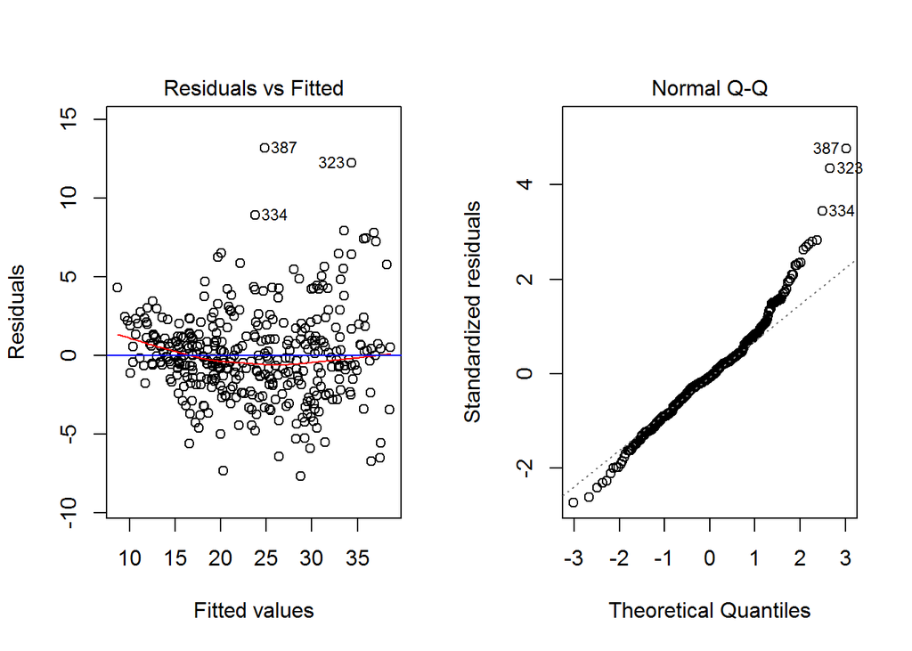

```r
par(mfrow=c(1,2))
plot(fit9,1)  #residual plot
abline(h=0,col="blue")
plot(fit9,2)  #qqplot
```

2. Summarize the effects found.

```r
summary(fit9)
```

```
##
## Call:
## lm(formula = mpg ~ cylinders + horsepower + weight + year + origin +
##     horsepower:origin + weight:origin + cylinders:year, data = auto_data2)
##
## Residuals:
##     Min      1Q  Median      3Q     Max
## -7.6789 -1.6181 -0.2007  1.2158 13.1813
##
## Coefficients:
##                      Estimate Std. Error t value Pr(>|t|)
## (Intercept)        -4.495e+01  3.381e+01  -1.329   0.1845
## cylinders4          1.426e+01  3.402e+01   0.419   0.6754
## cylinders5         -4.068e+02  1.666e+02  -2.443   0.0150 *
## cylinders6          3.524e+01  3.458e+01   1.019   0.3087
## cylinders8          5.451e+01  3.486e+01   1.564   0.1187
## horsepower         -1.159e-02  1.128e-02  -1.028   0.3046
## weight             -4.877e-03  5.201e-04  -9.377  < 2e-16 ***
## year                1.010e+00  4.471e-01   2.259   0.0245 *
## origin2             9.565e+00  2.201e+00   4.346 1.79e-05 ***
## origin3             1.156e+01  2.769e+00   4.177 3.69e-05 ***
## horsepower:origin2 -1.039e-01  2.571e-02  -4.041 6.46e-05 ***
## horsepower:origin3  1.213e-02  4.178e-02   0.290   0.7717
## weight:origin2      3.627e-04  1.087e-03   0.334   0.7387
## weight:origin3     -4.448e-03  2.208e-03  -2.015   0.0446 *
## cylinders4:year    -9.575e-02  4.502e-01  -0.213   0.8317
## cylinders5:year     5.232e+00  2.114e+00   2.475   0.0137 *
## cylinders6:year    -3.975e-01  4.570e-01  -0.870   0.3849
## cylinders8:year    -6.404e-01  4.603e-01  -1.391   0.1650
## ---
## Signif. codes:  0 '***' 0.001 '**' 0.01 '*' 0.05 '.' 0.1 ' ' 1
##
## Residual standard error: 2.849 on 374 degrees of freedom
## Multiple R-squared:  0.8725, Adjusted R-squared:  0.8667
## F-statistic: 150.6 on 17 and 374 DF,  p-value: < 2.2e-16
```

2. MPG has negative relationship with weight and horsepower, positive relationship with year and origin. MPG is also affected by interactive of year and different cylinders, most are negative effects but cylinder5:year. MPG is also affected by interactive of horsepower:origin and weight:origin
3. Predict the `mpg` of the following car: A red car built in the US in 1983 that is 180 inches long, has 8 cylinders, displaces 350 cu. inches, weighs 4000 pounds, and has a horsepower of 260. Also give a 95% CI for your prediction.

```r
newcar <- auto_data2[1,]
newcar[1,] <- NA
newcar["year"] <- 83
newcar["cylinders"] <- as.factor(8)
newcar["displacement"] <- 350
newcar["weight"] <- 4000
newcar["horsepower"] <- 260
newcar["origin"] <- as.factor(1)

predict(fit9,newcar, interval="confidence",se.fit=TRUE)
```

```
## $fit
##        fit     lwr      upr
## 1 17.70455 14.0013 21.40781
##
## $se.fit
## [1] 1.883336
##
## $df
## [1] 374
##
## $residual.scale
## [1] 2.849206
```

```r
# predicted mpg is 17.70455 with a 95% confidence interval of [14.0013, 21.40781]
```

predicted mpg is 17.70455 with a 95% confidence interval of [14.0013, 21.40781].

## Appendix

```r
simulate_lm <- function(n) {
  # note: `n` is an input but not used (don't worry about this hack)
  x <- seq(0, 1, length = 40)
  y <- 1 + 1.2 * x + rnorm(40, sd = 2)
  t_star <- qt(0.975, 38)
  lse <- lm(y ~ x)
  lse_out <- summary(lse)$coefficients
  se <- lse_out[2, 2]
  b1 <- lse_out[2, 1]
  upper_CI = b1 + t_star * se
  lower_CI = b1 - t_star * se
  return(data.frame(se, b1, upper_CI, lower_CI))
}

# this step runs the simulation 100 times,
# then matrix transposes the result so rows are observations
sim_results <- data.frame(t(sapply(X = 1:100, FUN = simulate_lm)))
```